# 1. Data Understanding

# Part B - Domain Banking Marketing

Bank is interested in increasing the Borrowers base rapidly by bringing in Business via Loan interests.

Last quarter campaign brought in an average single digit convertion rate.

Marketing department wants to increase the conversion ratio to double digits with same budget as per last campaign

Build a Machine Learning Model to perform focused marketing by predicting the potential customers who will convert using the historical dataset

# 1. Data Understanding & Preparation

```python
# 1A

data1_df = pd.read_csv("Data1.csv")
data2_df = pd.read_csv("Data2.csv")
```

```python
data1_df.head()
```

|  | ID | Age | CustomerSince | HighestSpend | ZipCode | HiddenScore | MonthlyAverageSpend | Level |
| --- | --- | --- | --- | --- | --- | --- | --- | --- |
| 0 | 1 | 25 | 1 | 49 | 91107 | 4 | 1.6 | 1 |
| 1 | 2 | 45 | 19 | 34 | 90089 | 3 | 1.5 | 1 |
| 2 | 3 | 39 | 15 | 11 | 94720 | 1 | 1.0 | 1 |
| 3 | 4 | 35 | 9 | 100 | 94112 | 1 | 2.7 | 2 |
| 4 | 5 | 35 | 8 | 45 | 91330 | 4 | 1.0 | 2 |

```python
data2_df.head()
```

|  | ID | Mortgage | Security | FixedDepositAccount | InternetBanking | CreditCard | LoanOnCard |
| --- | --- | --- | --- | --- | --- | --- | --- |
| 0 | 1 | 0 | 1 | 0 | 0 | 0 | NaN |
| 1 | 2 | 0 | 1 | 0 | 0 | 0 | NaN |
| 2 | 3 | 0 | 0 | 0 | 0 | 0 | NaN |
| 3 | 4 | 0 | 0 | 0 | 0 | 0 | NaN |
| 4 | 5 | 0 | 0 | 0 | 0 | 1 | NaN |

```python
data1_df.describe()
```

|  | ID | Age | CustomerSince | HighestSpend | ZipCode | HiddenScore | MonthlyAverageSpend | Level |
| --- | --- | --- | --- | --- | --- | --- | --- | --- |
| count | 5000.000000 | 5000.000000 | 5000.000000 | 5000.000000 | 5000.000000 | 5000.000000 | 5000.000000 | 5000.000000 |
| mean | 2500.500000 | 45.338400 | 20.104600 | 73.774200 | 93152.503000 | 2.396400 | 1.937938 | 1.881000 |
| std | 1443.520003 | 11.463166 | 11.467954 | 46.033729 | 2121.852197 | 1.147663 | 1.747659 | 0.839869 |
| min | 1.000000 | 23.000000 | -3.000000 | 8.000000 | 9307.000000 | 1.000000 | 0.000000 | 1.000000 |
| 25% | 1250.750000 | 35.000000 | 10.000000 | 39.000000 | 91911.000000 | 1.000000 | 0.700000 | 1.000000 |
| 50% | 2500.500000 | 45.000000 | 20.000000 | 64.000000 | 93437.000000 | 2.000000 | 1.500000 | 2.000000 |
| 75% | 3750.250000 | 55.000000 | 30.000000 | 98.000000 | 94608.000000 | 3.000000 | 2.500000 | 3.000000 |
| max | 5000.000000 | 67.000000 | 43.000000 | 224.000000 | 96651.000000 | 4.000000 | 10.000000 | 3.000000 |

```python
# 1B... datatypes

data1_df.dtypes
```

```
ID                       int64
Age                      int64
CustomerSince            int64
HighestSpend             int64
ZipCode                  int64
HiddenScore              int64
MonthlyAverageSpend    float64
Level                    int64
dtype: object
```

```python
data2_df.describe()
```

|  | ID | Mortgage | Security | FixedDepositAccount | InternetBanking | CreditCard | LoanOnCard |
| --- | --- | --- | --- | --- | --- | --- | --- |
| count | 5000.000000 | 5000.000000 | 5000.000000 | 5000.00000 | 5000.000000 | 5000.000000 | 4980.000000 |
| mean | 2500.500000 | 56.498800 | 0.104400 | 0.06040 | 0.596800 | 0.294000 | 0.096386 |
| std | 1443.520003 | 101.713802 | 0.305809 | 0.23825 | 0.490589 | 0.455637 | 0.295149 |
| min | 1.000000 | 0.000000 | 0.000000 | 0.00000 | 0.000000 | 0.000000 | 0.000000 |
| 25% | 1250.750000 | 0.000000 | 0.000000 | 0.00000 | 0.000000 | 0.000000 | 0.000000 |
| 50% | 2500.500000 | 0.000000 | 0.000000 | 0.00000 | 1.000000 | 0.000000 | 0.000000 |
| 75% | 3750.250000 | 101.000000 | 0.000000 | 0.00000 | 1.000000 | 1.000000 | 0.000000 |
| max | 5000.000000 | 635.000000 | 1.000000 | 1.00000 | 1.000000 | 1.000000 | 1.000000 |

```python
data2_df.dtypes
```

```
ID                       int64
Mortgage                 int64
Security                 int64
FixedDepositAccount      int64
InternetBanking          int64
CreditCard               int64
LoanOnCard             float64
dtype: object
```

```python
# 1B... Shape

data1_df.shape
```

```
(5000, 8)
```

```python
data2_df.shape
```

```
(5000, 7)
```

```python
# 1B... columns

data1_df.columns
```

```
Index(['ID', 'Age', 'CustomerSince', 'HighestSpend', 'ZipCode', 'HiddenScore',
       'MonthlyAverageSpend', 'Level'],
      dtype='object')
```

```python
data2_df.columns
```

```
Index(['ID', 'Mortgage', 'Security', 'FixedDepositAccount', 'InternetBanking',
       'CreditCard', 'LoanOnCard'],
      dtype='object')
```

```python
# 1C... Merging both the Dataframes on ID

comb_df = pd.merge(data1_df, data2_df, on='ID')
```

```python
comb_df.shape
```

```
(5000, 14)
```

```python
comb_df.columns
```

```
Index(['ID', 'Age', 'CustomerSince', 'HighestSpend', 'ZipCode', 'HiddenScore',
       'MonthlyAverageSpend', 'Level', 'Mortgage', 'Security',
       'FixedDepositAccount', 'InternetBanking', 'CreditCard', 'LoanOnCard'],
      dtype='object')
```

```python
# 1D.... Changing Datatypes

comb_df['CreditCard']          = comb_df['CreditCard'].astype('object')
comb_df['InternetBanking']     = comb_df['InternetBanking'].astype('object')
comb_df['FixedDepositAccount'] = comb_df['FixedDepositAccount'].astype('object')
comb_df['Security']            = comb_df['Security'].astype('object')
comb_df['Level']               = comb_df['Level'].astype('object')
comb_df['HiddenScore']         = comb_df['HiddenScore'].astype('object')
```

```python
comb_df.dtypes
```

```
ID                       int64
Age                      int64
CustomerSince            int64
HighestSpend             int64
ZipCode                  int64
HiddenScore             object
MonthlyAverageSpend    float64
Level                   object
Mortgage                 int64
Security                object
FixedDepositAccount     object
InternetBanking         object
CreditCard              object
LoanOnCard             float64
dtype: object
```

# 2. Data Exploration & Analysis

```python
old_df = comb_df
```

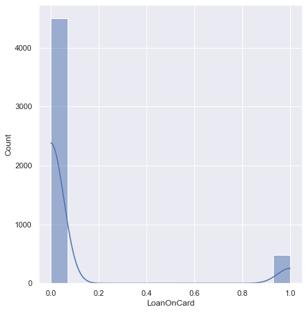

```python
# 2A........ Visualize distribution of Target variable "LoanOnCard"

sns.set(rc={'figure.figsize':(6.7,7.27)})
sns.histplot(comb_df['LoanOnCard'], kde=True)
```

```python
comb_df['LoanOnCard'].unique()
```

```
array([nan,  1.,  0.])
```

```python
comb_df['LoanOnCard'].value_counts()
```

```
0.0    4500
1.0     480
Name: LoanOnCard, dtype: int64
```

There are 4500 Zeros (0 - No Loans on Card) and 480 Ones (1 - Loans taken on Card) which means 9.6% customers have taken Loan on Cards....

```python
# 2B... Checking missing values.

comb_df['LoanOnCard'].isnull().values.any()
```

```
True
```

```python
# 2B

comb_df['LoanOnCard'].isnull().sum()
```

```
20
```

```python
# 2B... checking missing values.

# There are 20 missing values in the Target variable, it might not be a good idea to impute the Target variable and hence I am
# going to remove these 20 rows from the dataset
```

```python
# 2B... dropping those unwanted rows

new_df = comb_df.dropna(subset = ['LoanOnCard'])
```

```python
new_df.shape
```

```
(4980, 14)
```

```python
comb_df.shape
```

```
(5000, 14)
```

```python
comb_df['HiddenScore'].unique()
```

```
array([4, 3, 1, 2], dtype=object)
```

```python
comb_df['HiddenScore'].isnull().sum()
```

```
0
```

```python
comb_df['Level'].unique()
```

```
array([1, 2, 3], dtype=object)
```

```python
comb_df['Level'].isnull().sum()
```

```
0
```

```python
comb_df['Security'].unique()
```

```
array([1, 0], dtype=object)
```

```python
comb_df['Security'].isnull().sum()
```

```
0
```

```python
comb_df['FixedDepositAccount'].unique()
```

```
array([0, 1], dtype=object)
```

```python
comb_df['FixedDepositAccount'].isnull().sum()
```

```
0
```

```python
comb_df['InternetBanking'].unique()
```

```
array([0, 1], dtype=object)
```

```python
comb_df['InternetBanking'].isnull().sum()
```

```
0
```

```python
comb_df['CreditCard'].unique()
```

```
array([0, 1], dtype=object)
```

```python
comb_df['CreditCard'].isnull().sum()
```

```
0
```

```python
# 2C..... Have checked all the Categorical variables ..

# HiddenScore, Level, Security, FixedDepositAccount, InternetBanking & CreditCard

# There are no null values, no unexpected values anywhere in these variables, data seem to be nice and clean.
```

# 3. Data Preparation & Modeling

```python
# 3A... Dropping Zipcode & LoanOnCard and splitting X & y

X = new_df.drop(['ID','ZipCode','LoanOnCard'],axis=1)     # Predictor class
y = new_df['LoanOnCard']   # Predicted class
```

```python
y
```

```
9       1.0
10      0.0
11      0.0
12      0.0
13      0.0
       ...
4995    0.0
4996    0.0
4997    0.0
4998    0.0
4999    0.0
Name: LoanOnCard, Length: 4980, dtype: float64
```

```python
X
```

|  | Age | CustomerSince | HighestSpend | HiddenScore | MonthlyAverageSpend | Level | Mortgage | Security | FixedDepositAccount | InternetBanking | CreditCard |
| --- | --- | --- | --- | --- | --- | --- | --- | --- | --- | --- | --- |
| 9 | 34 | 9 | 180 | 1 | 8.9 | 3 | 0 | 0 | 0 | 0 | 0 |
| 10 | 65 | 39 | 105 | 4 | 2.4 | 3 | 0 | 0 | 0 | 0 | 0 |
| 11 | 29 | 5 | 45 | 3 | 0.1 | 2 | 0 | 0 | 0 | 1 | 0 |
| 12 | 48 | 23 | 114 | 2 | 3.8 | 3 | 0 | 1 | 0 | 0 | 0 |
| 13 | 59 | 32 | 40 | 4 | 2.5 | 2 | 0 | 0 | 0 | 1 | 0 |
| ... | ... | ... | ... | ... | ... | ... | ... | ... | ... | ... | ... |
| 4995 | 29 | 3 | 40 | 1 | 1.9 | 3 | 0 | 0 | 0 | 1 | 0 |
| 4996 | 30 | 4 | 15 | 4 | 0.4 | 1 | 85 | 0 | 0 | 1 | 0 |
| 4997 | 63 | 39 | 24 | 2 | 0.3 | 3 | 0 | 0 | 0 | 0 | 0 |
| 4998 | 65 | 40 | 49 | 3 | 0.5 | 2 | 0 | 0 | 0 | 1 | 0 |
| 4999 | 28 | 4 | 83 | 3 | 0.8 | 1 | 0 | 0 | 0 | 1 | 1 |

4980 rows × 11 columns

```python
# 3B.... train & test split with 25% in test

x_train, x_test, y_train, y_test = train_test_split(X, y, test_size=0.25, random_state=1)
# 1 is just any random seed number

x_train.head()
```

|  | Age | CustomerSince | HighestSpend | HiddenScore | MonthlyAverageSpend | Level | Mortgage | Security | FixedDepositAccount | InternetBanking | CreditCard |
| --- | --- | --- | --- | --- | --- | --- | --- | --- | --- | --- | --- |
| 3980 | 46 | 22 | 89 | 4 | 1.4 | 2 | 0 | 0 | 0 | 1 | 0 |
| 4489 | 39 | 13 | 21 | 3 | 0.2 | 2 | 0 | 0 | 0 | 1 | 0 |
| 4414 | 33 | 8 | 178 | 3 | 8.5 | 1 | 0 | 1 | 1 | 1 | 0 |
| 877 | 35 | 11 | 59 | 4 | 0.1 | 2 | 0 | 0 | 0 | 0 | 0 |
| 4390 | 52 | 26 | 62 | 4 | 2.8 | 2 | 0 | 0 | 0 | 1 | 0 |

```python
y_train.dtypes
```

```
dtype('float64')
```

```python
y_train.unique()
```

```
array([0., 1.])
```

```python
y_train.isnull().values.any()
```

```
False
```

```python
y_test.isnull().sum()
```

```
0
```

```python
y_test.unique()
```

```
array([0., 1.])
```

```python
y_train.value_counts()
```

```
0.0    3382
1.0     353
Name: LoanOnCard, dtype: int64
```

```python
y_test.value_counts()
```

```
0.0    1118
1.0     127
Name: LoanOnCard, dtype: int64
```

```python
# 3C.... Train Logistic Regression model

from sklearn import metrics

from sklearn.linear_model import LogisticRegression

# Fit the model on train
model = LogisticRegression(solver="liblinear")
model.fit(x_train, y_train)
#predict on test
y_predict = model.predict(x_test)


coef_df = pd.DataFrame(model.coef_)
coef_df['intercept'] = model.intercept_
print(coef_df)
```

```
         0         1         2         3         4        5         6  \
0 -0.41497  0.415445  0.050564  0.580127  0.115391  1.71864  0.000397

          7         8         9        10  intercept
0 -0.669608  3.233102 -0.599966 -0.844486  -2.132368
```

```python
model_score = model.score(x_test, y_test)
print(model_score)
```

```
0.9477911646586346
```

```python
print(y_test)
```

```
4378    0.0
268     0.0
3906    0.0
4099    0.0
3011    0.0
       ...
734     0.0
3835    1.0
4368    0.0
4548    0.0
2743    0.0
Name: LoanOnCard, Length: 1245, dtype: float64
```

```python
print(y_predict)
```

```
[0. 0. 0. ... 0. 0. 0.]
```

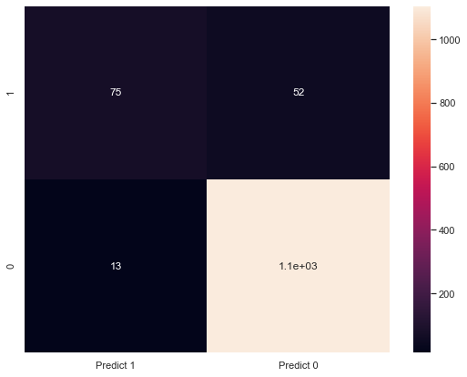

```python
cm=metrics.confusion_matrix(y_test, y_predict, labels=[1, 0])

df_cm = pd.DataFrame(cm, index = [i for i in ["1","0"]],
                  columns = [i for i in ["Predict 1","Predict 0"]])
plt.figure(figsize = (9,7))
sns.heatmap(df_cm, annot=True)
```

```python
# 3D.... Printing Evaluation Metrics

accuracy = metrics.accuracy_score(y_test, y_predict)
print('Accuracy : %f' % accuracy)

# precision tp / (tp + fp)
precision = metrics.precision_score(y_test, y_predict)
print('Precision: %f' % precision)

# recall: tp / (tp + fn)
recall = metrics.recall_score(y_test, y_predict)
print('Recall   : %f' % recall)

# f1: 2 tp / (2 tp + fp + fn)
f1 = metrics.f1_score(y_test, y_predict)
print('F1 score : %f' % f1)

roc = metrics.roc_auc_score(y_test, y_predict)
print('ROC score: %f' % roc)
```

```
Accuracy : 0.947791
Precision: 0.852273
Recall   : 0.590551
F1 score : 0.697674
ROC score: 0.789462
```

```python
# 3E... Balancing with SMOTE

!pip install -U imbalanced-learn

#!pip install imblearn
```

```python
# 3E... Balancing with SMOTE

from imblearn.over_sampling import SMOTE
```

```python
sm = SMOTE(random_state=42)
x_res, y_res = sm.fit_resample(x_train, y_train)
```

```python
y_res.value_counts()
```

```
0.0    3382
1.0    3382
Name: LoanOnCard, dtype: int64
```

```python
y_train.count()
```

```
3735
```

```python
y_test.count()
```

```
1245
```

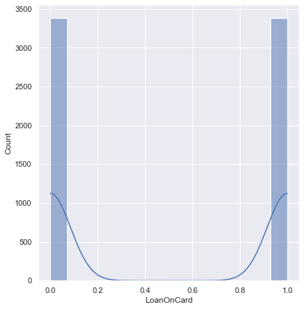

```python
sns.histplot(y_res, kde=True)
```

The initial Imbalanced data with Majority class of "LoanOnCard = 0" & Minority Class of "LoanOnCard = 1" have been equally Balanced with both becoming 50:50

```python
# 3F....Fitting the model on Balanced training data
model = LogisticRegression(solver="liblinear")
model.fit(x_res, y_res)
```

```
LogisticRegression(solver='liblinear')
```

```python
y_new_pred = model.predict(x_test)

coef_df = pd.DataFrame(model.coef_)
coef_df['intercept'] = model.intercept_
print(coef_df)
```

```
          0         1         2         3        4         5         6  \
0 -0.266679  0.267736  0.054809  0.649159  0.25265  1.631492 -0.000298

          7        8         9        10  intercept
0 -1.003785  4.27315 -0.853606 -0.788296  -4.510142
```

```python
model_score = model.score(x_test, y_test)
print(model_score)
```

```
0.8939759036144578
```

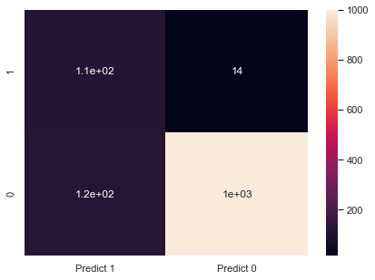

```python
cm=metrics.confusion_matrix(y_test, y_new_pred, labels=[1, 0])

df_cm = pd.DataFrame(cm, index = [i for i in ["1","0"]],
                  columns = [i for i in ["Predict 1","Predict 0"]])
plt.figure(figsize = (7,5))
sns.heatmap(df_cm, annot=True)
```

```python
accuracy = metrics.accuracy_score(y_test, y_new_pred)
print('Accuracy : %f' % accuracy)

# precision tp / (tp + fp)
precision = metrics.precision_score(y_test, y_new_pred)
print('Precision: %f' % precision)

# recall: tp / (tp + fn)
recall = metrics.recall_score(y_test, y_new_pred)
print('Recall   : %f' % recall)

# f1: 2 tp / (2 tp + fp + fn)
f1 = metrics.f1_score(y_test, y_new_pred)
print('F1 score : %f' % f1)

roc = metrics.roc_auc_score(y_test, y_new_pred)
print('ROC score: %f' % roc)
```

```
Accuracy : 0.893976
Precision: 0.489177
Recall   : 0.889764
F1 score : 0.631285
ROC score: 0.892109
```

Accuracy: 0.947791 Precision: 0.852273 Recall: 0.590551 F1 score: 0.697674 ROC score: 0.789462

after Balancing the Training set to get a 50:50%, the evaluation metrics changed to

Accuracy: 0.893976 Precision: 0.489177 Recall: 0.889764 F1 score: 0.631285 ROC score: 0.892109

```
a) A Slight dip of 5% in the accurancy - (from 94% to 89%)
b) major dip in the Precision - 47% - almost half (from 85% to 49%)
c) a good 30% increase in the Recall - (from 59% to 89%)
d) a slight dip in F1 score since Precision went down heavily and Recall did not go up that much (from 69% to 63%)
e) a good increase in ROC score - (from 79% to 89%)
```

# 4. Performance Improvement

```python
# 4A....

from sklearn.model_selection import train_test_split
from sklearn.neighbors import KNeighborsClassifier
import scipy.stats as stats

from sklearn.preprocessing import StandardScaler
from sklearn.preprocessing import MinMaxScaler
from sklearn.preprocessing import RobustScaler

from sklearn.metrics import roc_auc_score
```

```python
# 4A... Training base model for KNN

NNH = KNeighborsClassifier(n_neighbors= 5, weights = 'distance' )
NNH.fit(x_res, y_res)

#Predict testing set
y_pred_new = NNH.predict(x_test)
#Check performance using accuracy
print("KNN - Accuracy ",metrics.accuracy_score(y_test, y_pred_new))
print("KNN - Precision",metrics.precision_score(y_test, y_pred_new))
print("KNN - Recall   ",metrics.recall_score(y_test, y_pred_new))
print("KNN - F1 score ",metrics.f1_score(y_test, y_pred_new))
print("KNN - ROC      ",metrics.roc_auc_score(y_test, y_pred_new))
```

```
KNN - Accuracy  0.8578313253012049
KNN - Precision 0.40310077519379844
KNN - Recall    0.8188976377952756
KNN - F1 score  0.5402597402597403
KNN - ROC       0.840575831419999
```

```python
x_res
```

|  | Age | CustomerSince | HighestSpend | HiddenScore | MonthlyAverageSpend | Level | Mortgage | Security | FixedDepositAccount | InternetBanking | CreditCard |
| --- | --- | --- | --- | --- | --- | --- | --- | --- | --- | --- | --- |
| 0 | 46 | 22 | 89 | 4 | 1.400000 | 2 | 0 | 0 | 0 | 1 | 0 |
| 1 | 39 | 13 | 21 | 3 | 0.200000 | 2 | 0 | 0 | 0 | 1 | 0 |
| 2 | 33 | 8 | 178 | 3 | 8.500000 | 1 | 0 | 1 | 1 | 1 | 0 |
| 3 | 35 | 11 | 59 | 4 | 0.100000 | 2 | 0 | 0 | 0 | 0 | 0 |
| 4 | 52 | 26 | 62 | 4 | 2.800000 | 2 | 0 | 0 | 0 | 1 | 0 |
| ... | ... | ... | ... | ... | ... | ... | ... | ... | ... | ... | ... |
| 6759 | 45 | 20 | 119 | 1 | 4.975376 | 3 | 161 | 0 | 0 | 0 | 0 |
| 6760 | 50 | 25 | 130 | 1 | 1.072541 | 2 | 0 | 0 | 0 | 0 | 0 |
| 6761 | 28 | 3 | 115 | 3 | 3.108111 | 2 | 0 | 0 | 0 | 0 | 0 |
| 6762 | 35 | 11 | 180 | 1 | 3.838155 | 2 | 569 | 0 | 0 | 0 | 0 |
| 6763 | 40 | 15 | 173 | 3 | 5.846385 | 1 | 0 | 0 | 0 | 1 | 0 |

6764 rows × 11 columns

```python
# 4A..... Training base model for SVM

from sklearn.svm import SVC

clf = SVC(kernel='linear')

# fitting x samples and y classes
clf.fit(x_res, y_res)
```

```
SVC(kernel='linear')
```

```python
y_pred_svm = clf.predict(x_test)
```

```python
print("SVC - Accuracy ",metrics.accuracy_score(y_test, y_pred_svm))
print("SVC - Precision",metrics.precision_score(y_test, y_pred_svm))
print("SVC - Recall   ",metrics.recall_score(y_test, y_pred_svm))
print("SVC - F1 Score ",metrics.f1_score(y_test, y_pred_svm))
print("SVC - ROC Score",metrics.roc_auc_score(y_test, y_pred_svm))
```

```
SVC - Accuracy  0.891566265060241
SVC - Precision 0.4831932773109244
SVC - Recall    0.905511811023622
SVC - F1 Score  0.6301369863013698
SVC - ROC Score 0.8977469609679827
```

```python
# 4A.... Evaluation metrics for KNN on base model

KNN - Accuracy  0.8578313253012049
KNN - Precision 0.40310077519379844
KNN - Recall    0.8188976377952756
KNN - F1 score  0.5402597402597403
KNN - ROC       0.840575831419999

# 4A... Evaluation metrics for SVM on the base model

SVC - Accuracy  0.891566265060241
SVC - Precision 0.4831932773109244
SVC - Recall    0.905511811023622
SVC - F1 Score  0.6301369863013698
SVC - ROC Score 0.8977469609679827
```

```python
# 4B.... Tuning parameters for SVC.......... Changing kernel from linear to rbf, and introducing gamma

clf = SVC(kernel='rbf',C = 1.0,gamma='auto')

# fitting x samples and y classes
clf.fit(x_res, y_res)

y_pred_svm = clf.predict(x_test)

print("SVC Tuning with rbf, C=1, gamma='auto' - Accuracy ",metrics.accuracy_score(y_test, y_pred_svm))
print("SVC Tuning with rbf, C=1, gamma='auto' - Precision",metrics.precision_score(y_test, y_pred_svm))
print("SVC Tuning with rbf, C=1, gamma='auto' - Recall   ",metrics.recall_score(y_test, y_pred_svm))
print("SVC Tuning with rbf, C=1, gamma='auto' - F1 Score ",metrics.f1_score(y_test, y_pred_svm))
print("SVC Tuning with rbf, C=1, gamma='auto' - ROC Score",metrics.roc_auc_score(y_test, y_pred_svm))
```

```
SVC Tuning with rbf, C=1, gamma='auto' - Accuracy  0.9052208835341365
SVC Tuning with rbf, C=1, gamma='auto' - Precision 0.5671641791044776
SVC Tuning with rbf, C=1, gamma='auto' - Recall    0.2992125984251969
SVC Tuning with rbf, C=1, gamma='auto' - F1 Score  0.3917525773195876
SVC Tuning with rbf, C=1, gamma='auto' - ROC Score 0.6366367106616144
```

```python
clf = SVC(kernel='rbf',C = 1.0,gamma=0.1)

# fitting x samples and y classes
clf.fit(x_res, y_res)

y_pred_svm = clf.predict(x_test)

print("SVC Tuning with rbf, C=1, gamma=0.1 - Accuracy ",metrics.accuracy_score(y_test, y_pred_svm))
print("SVC Tuning with rbf, C=1, gamma=0.1 - Precision",metrics.precision_score(y_test, y_pred_svm))
print("SVC Tuning with rbf, C=1, gamma=0.1 - Recall   ",metrics.recall_score(y_test, y_pred_svm))
print("SVC Tuning with rbf, C=1, gamma=0.1 - F1 Score ",metrics.f1_score(y_test, y_pred_svm))
print("SVC Tuning with rbf, C=1, gamma=0.1 - ROC Score",metrics.roc_auc_score(y_test, y_pred_svm))
```

```
SVC Tuning with rbf, C=1, gamma=0.1 - Accuracy  0.9036144578313253
SVC Tuning with rbf, C=1, gamma=0.1 - Precision 0.5538461538461539
SVC Tuning with rbf, C=1, gamma=0.1 - Recall    0.28346456692913385
SVC Tuning with rbf, C=1, gamma=0.1 - F1 Score  0.37500000000000006
SVC Tuning with rbf, C=1, gamma=0.1 - ROC Score 0.6287626949135829
```

```python
clf = SVC(kernel='rbf',C = 10.0,gamma=0.1)

# fitting x samples and y classes
clf.fit(x_res, y_res)

y_pred_svm = clf.predict(x_test)

print("SVC Tuning with rbf, C=10, gamma=0.1 - Accuracy ",metrics.accuracy_score(y_test, y_pred_svm))
print("SVC Tuning with rbf, C=10, gamma=0.1 - Precision",metrics.precision_score(y_test, y_pred_svm))
print("SVC Tuning with rbf, C=10, gamma=0.1 - Recall   ",metrics.recall_score(y_test, y_pred_svm))
print("SVC Tuning with rbf, C=10, gamma=0.1 - F1 Score ",metrics.f1_score(y_test, y_pred_svm))
print("SVC Tuning with rbf, C=10, gamma=0.1 - ROC Score",metrics.roc_auc_score(y_test, y_pred_svm))
```

```
SVC Tuning with rbf, C=10, gamma=0.1 - Accuracy  0.9092369477911647
SVC Tuning with rbf, C=10, gamma=0.1 - Precision 0.609375
SVC Tuning with rbf, C=10, gamma=0.1 - Recall    0.30708661417322836
SVC Tuning with rbf, C=10, gamma=0.1 - F1 Score  0.4083769633507853
SVC Tuning with rbf, C=10, gamma=0.1 - ROC Score 0.6423626273012832
```

```python
clf = SVC(kernel='rbf',C = 10.0,gamma=0.01)

# fitting x samples and y classes
clf.fit(x_res, y_res)

y_pred_svm = clf.predict(x_test)

print("SVC Tuning with rbf, C=10, gamma=0.01 - Accuracy ",metrics.accuracy_score(y_test, y_pred_svm))
print("SVC Tuning with rbf, C=10, gamma=0.01 - Precision",metrics.precision_score(y_test, y_pred_svm))
print("SVC Tuning with rbf, C=10, gamma=0.01 - Recall   ",metrics.recall_score(y_test, y_pred_svm))
print("SVC Tuning with rbf, C=10, gamma=0.01 - F1 Score ",metrics.f1_score(y_test, y_pred_svm))
print("SVC Tuning with rbf, C=10, gamma=0.01 - ROC Score",metrics.roc_auc_score(y_test, y_pred_svm))
```

```
SVC Tuning with rbf, C=10, gamma=0.01 - Accuracy  0.9196787148594378
SVC Tuning with rbf, C=10, gamma=0.01 - Precision 0.6153846153846154
SVC Tuning with rbf, C=10, gamma=0.01 - Recall    0.5669291338582677
SVC Tuning with rbf, C=10, gamma=0.01 - F1 Score  0.5901639344262296
SVC Tuning with rbf, C=10, gamma=0.01 - ROC Score 0.7633393433155381
```

```python
clf = SVC(kernel='rbf',C = 100.0,gamma=0.01)

# fitting x samples and y classes
clf.fit(x_res, y_res)

y_pred_svm = clf.predict(x_test)

print("SVC Tuning with rbf, C=100, gamma=0.01 - Accuracy ",metrics.accuracy_score(y_test, y_pred_svm))
print("SVC Tuning with rbf, C=100, gamma=0.01 - Precision",metrics.precision_score(y_test, y_pred_svm))
print("SVC Tuning with rbf, C=100, gamma=0.01 - Recall   ",metrics.recall_score(y_test, y_pred_svm))
print("SVC Tuning with rbf, C=100, gamma=0.01 - F1 Score ",metrics.f1_score(y_test, y_pred_svm))
print("SVC Tuning with rbf, C=100, gamma=0.01 - ROC Score",metrics.roc_auc_score(y_test, y_pred_svm))
```

```
SVC Tuning with rbf, C=100, gamma=0.01 - Accuracy  0.9236947791164659
SVC Tuning with rbf, C=100, gamma=0.01 - Precision 0.6454545454545455
SVC Tuning with rbf, C=100, gamma=0.01 - Recall    0.5590551181102362
SVC Tuning with rbf, C=100, gamma=0.01 - F1 Score  0.5991561181434599
SVC Tuning with rbf, C=100, gamma=0.01 - ROC Score 0.7620856985900019
```

```python
clf = SVC(kernel='rbf',C = 100.0,gamma=0.001)

# fitting x samples and y classes
clf.fit(x_res, y_res)

y_pred_svm = clf.predict(x_test)

print("SVC Tuning with rbf, C=100, gamma=0.001 - Accuracy ",metrics.accuracy_score(y_test, y_pred_svm))
print("SVC Tuning with rbf, C=100, gamma=0.001 - Precision",metrics.precision_score(y_test, y_pred_svm))
print("SVC Tuning with rbf, C=100, gamma=0.001 - Recall   ",metrics.recall_score(y_test, y_pred_svm))
print("SVC Tuning with rbf, C=100, gamma=0.001 - F1 Score ",metrics.f1_score(y_test, y_pred_svm))
print("SVC Tuning with rbf, C=100, gamma=0.001 - ROC Score",metrics.roc_auc_score(y_test, y_pred_svm))
```

```
SVC Tuning with rbf, C=100, gamma=0.001 - Accuracy  0.940562248995984
SVC Tuning with rbf, C=100, gamma=0.001 - Precision 0.6879432624113475
SVC Tuning with rbf, C=100, gamma=0.001 - Recall    0.7637795275590551
SVC Tuning with rbf, C=100, gamma=0.001 - F1 Score  0.7238805970149254
SVC Tuning with rbf, C=100, gamma=0.001 - ROC Score 0.8622117673573451
```

```python
clf = SVC(kernel='rbf',C = 100.0,gamma=0.0001)

# fitting x samples and y classes
clf.fit(x_res, y_res)

y_pred_svm = clf.predict(x_test)

print("SVC Tuning with rbf, C=100, gamma=0.0001 - Accuracy ",metrics.accuracy_score(y_test, y_pred_svm))
print("SVC Tuning with rbf, C=100, gamma=0.0001 - Precision",metrics.precision_score(y_test, y_pred_svm))
print("SVC Tuning with rbf, C=100, gamma=0.0001 - Recall   ",metrics.recall_score(y_test, y_pred_svm))
print("SVC Tuning with rbf, C=100, gamma=0.0001 - F1 Score ",metrics.f1_score(y_test, y_pred_svm))
print("SVC Tuning with rbf, C=100, gamma=0.0001 - ROC Score",metrics.roc_auc_score(y_test, y_pred_svm))
```

```
SVC Tuning with rbf, C=100, gamma=0.0001 - Accuracy  0.927710843373494
SVC Tuning with rbf, C=100, gamma=0.0001 - Precision 0.5978835978835979
SVC Tuning with rbf, C=100, gamma=0.0001 - Recall    0.889763779527559
SVC Tuning with rbf, C=100, gamma=0.0001 - F1 Score  0.7151898734177214
SVC Tuning with rbf, C=100, gamma=0.0001 - ROC Score 0.9108926232163734
```

```python
clf = SVC(kernel='linear',C = 0.1)

# fitting x samples and y classes
clf.fit(x_res, y_res)

y_pred_svm = clf.predict(x_test)

print("SVC Tuning with linear, C=0.1 - Accuracy ",metrics.accuracy_score(y_test, y_pred_svm))
print("SVC Tuning with linear, C=0.1 - Precision",metrics.precision_score(y_test, y_pred_svm))
print("SVC Tuning with linear, C=0.1 - Recall   ",metrics.recall_score(y_test, y_pred_svm))
print("SVC Tuning with linear, C=0.1 - F1 Score ",metrics.f1_score(y_test, y_pred_svm))
print("SVC Tuning with linear, C=0.1 - ROC Score",metrics.roc_auc_score(y_test, y_pred_svm))
```

```
SVC Tuning with linear, C=0.1 - Accuracy  0.8899598393574297
SVC Tuning with linear, C=0.1 - Precision 0.4793388429752066
SVC Tuning with linear, C=0.1 - Recall    0.9133858267716536
SVC Tuning with linear, C=0.1 - F1 Score  0.6287262872628726
SVC Tuning with linear, C=0.1 - ROC Score 0.9003422872677589
```

```python
clf = SVC(kernel='linear',C = 1.0)

# fitting x samples and y classes
clf.fit(x_res, y_res)

y_pred_svm = clf.predict(x_test)

print("SVC Tuning with linear, C=1 - Accuracy ",metrics.accuracy_score(y_test, y_pred_svm))
print("SVC Tuning with linear, C=1 - Precision",metrics.precision_score(y_test, y_pred_svm))
print("SVC Tuning with linear, C=1 - Recall   ",metrics.recall_score(y_test, y_pred_svm))
print("SVC Tuning with linear, C=1 - F1 Score ",metrics.f1_score(y_test, y_pred_svm))
print("SVC Tuning with linear, C=1 - ROC Score",metrics.roc_auc_score(y_test, y_pred_svm))
```

```
SVC Tuning with linear, C=1 - Accuracy  0.891566265060241
SVC Tuning with linear, C=1 - Precision 0.4831932773109244
SVC Tuning with linear, C=1 - Recall    0.905511811023622
SVC Tuning with linear, C=1 - F1 Score  0.6301369863013698
SVC Tuning with linear, C=1 - ROC Score 0.8977469609679827
```

```python
clf = SVC(kernel='linear',C = 10.0)

# fitting x samples and y classes
clf.fit(x_res, y_res)

y_pred_svm = clf.predict(x_test)

print("SVC Tuning with linear, C=10 - Accuracy ",metrics.accuracy_score(y_test, y_pred_svm))
print("SVC Tuning with linear, C=10 - Precision",metrics.precision_score(y_test, y_pred_svm))
print("SVC Tuning with linear, C=10 - Recall   ",metrics.recall_score(y_test, y_pred_svm))
print("SVC Tuning with linear, C=10 - F1 Score ",metrics.f1_score(y_test, y_pred_svm))
print("SVC Tuning with linear, C=10 - ROC Score",metrics.roc_auc_score(y_test, y_pred_svm))
```

```
SVC Tuning with linear, C=10 - Accuracy  0.8899598393574297
SVC Tuning with linear, C=10 - Precision 0.4791666666666667
SVC Tuning with linear, C=10 - Recall    0.905511811023622
SVC Tuning with linear, C=10 - F1 Score  0.6267029972752043
SVC Tuning with linear, C=10 - ROC Score 0.8968525065851563
```

```python
clf = SVC(kernel='linear',C = 100.0)

# fitting x samples and y classes
clf.fit(x_res, y_res)

y_pred_svm = clf.predict(x_test)

print("SVC Tuning with linear, C=100 - Accuracy ",metrics.accuracy_score(y_test, y_pred_svm))
print("SVC Tuning with linear, C=100 - Precision",metrics.precision_score(y_test, y_pred_svm))
print("SVC Tuning with linear, C=100 - Recall   ",metrics.recall_score(y_test, y_pred_svm))
print("SVC Tuning with linear, C=100 - F1 Score ",metrics.f1_score(y_test, y_pred_svm))
print("SVC Tuning with linear, C=100 - ROC Score",metrics.roc_auc_score(y_test, y_pred_svm))
```

```
SVC Tuning with linear, C=100 - Accuracy  0.8979919678714859
SVC Tuning with linear, C=100 - Precision 0.5
SVC Tuning with linear, C=100 - Recall    0.8976377952755905
SVC Tuning with linear, C=100 - F1 Score  0.6422535211267606
SVC Tuning with linear, C=100 - ROC Score 0.8978349978166862
```

```python
svc= SVC()
parameters = [{"kernel": ["rbf"],"gamma":[0.1,0.01],"C":[0.1,1,10]},
              {"kernel": ["linear"],"C": [0.1,1,10]}]

cv = GridSearchCV(svc,parameters,cv=5)
cv.fit(x_res,y_res)

def display(results):
    print(f'Best parameters are: {results.best_params_}')
    mean_score = results.cv_results_['mean_test_score']
    std_score = results.cv_results_['std_test_score']
    params = results.cv_results_['params']
    for mean,std,params in zip(mean_score,std_score,params):
        print(f'{round(mean,2)} + or -{round(std,2)} for the {params}')

display(cv)
```

```
Best parameters are: {'C': 10, 'gamma': 0.01, 'kernel': 'rbf'}
0.79 + or -0.01 for the {'C': 0.1, 'gamma': 0.1, 'kernel': 'rbf'}
0.9 + or -0.01 for the {'C': 0.1, 'gamma': 0.01, 'kernel': 'rbf'}
0.93 + or -0.01 for the {'C': 1, 'gamma': 0.1, 'kernel': 'rbf'}
0.94 + or -0.0 for the {'C': 1, 'gamma': 0.01, 'kernel': 'rbf'}
0.94 + or -0.02 for the {'C': 10, 'gamma': 0.1, 'kernel': 'rbf'}
0.98 + or -0.0 for the {'C': 10, 'gamma': 0.01, 'kernel': 'rbf'}
0.91 + or -0.01 for the {'C': 0.1, 'kernel': 'linear'}
0.91 + or -0.0 for the {'C': 1, 'kernel': 'linear'}
0.91 + or -0.0 for the {'C': 10, 'kernel': 'linear'}
```

Tuning just the neighbours and specifying leaf_size and p values

```python
knn = KNeighborsClassifier(n_neighbors= 3, weights = 'distance',leaf_size=1,p=1)

#Training the model
knn.fit(x_res, y_res)
#Predict testing set
y_pred_new = knn.predict(x_test)

print("With neighbours 3, leaf = 1, p=1 - Accuracy ",metrics.accuracy_score(y_test, y_pred_new))
print("With neighbours 3, leaf = 1, p=1 - Precision",metrics.precision_score(y_test, y_pred_new))
print("With neighbours 3, leaf = 1, p=1 - Recall   ",metrics.recall_score(y_test, y_pred_new))
print("With neighbours 3, leaf = 1, p=1 - F1 score ",metrics.f1_score(y_test, y_pred_new))
```

```
With neighbours 3, leaf = 1, p=1 - Accuracy  0.9036144578313253
With neighbours 3, leaf = 1, p=1 - Precision 0.5191256830601093
With neighbours 3, leaf = 1, p=1 - Recall    0.7480314960629921
With neighbours 3, leaf = 1, p=1 - F1 score  0.6129032258064516
```

```python
knn = KNeighborsClassifier(n_neighbors= 3, weights = 'uniform',leaf_size=1,p=1)

#Training the model
knn.fit(x_res, y_res)
#Predict testing set
y_pred_new = knn.predict(x_test)

print("With neighbours 3, weights=uniform, leaf = 1, p=1 - Accuracy ",metrics.accuracy_score(y_test, y_pred_new))
print("With neighbours 3, weights=uniform, leaf = 1, p=1 - Precision",metrics.precision_score(y_test, y_pred_new))
print("With neighbours 3, weights=uniform, leaf = 1, p=1 - Recall   ",metrics.recall_score(y_test, y_pred_new))
print("With neighbours 3, weights=uniform, leaf = 1, p=1 - F1 score ",metrics.f1_score(y_test, y_pred_new))
```

```
With neighbours 3, weights=uniform, leaf = 1, p=1 - Accuracy  0.9004016064257028
With neighbours 3, weights=uniform, leaf = 1, p=1 - Precision 0.5077720207253886
With neighbours 3, weights=uniform, leaf = 1, p=1 - Recall    0.7716535433070866
With neighbours 3, weights=uniform, leaf = 1, p=1 - F1 score  0.6125
```

```python
Tuning parameters for KNN.... by using StandardScaler
```

```python
#Create copy of dataset.
x_scaled = x_res.copy()
#Rescaling features Age, CustomerSince, HighestSpend, MonthlyAverageSpend, Level, Mortgage.
scaler = StandardScaler()
features = [['Age', 'CustomerSince', 'HighestSpend', 'HiddenScore','MonthlyAverageSpend', 'Level', 'Mortgage']]
for feature in features:
    x_scaled[feature] = scaler.fit_transform(x_scaled[feature])
#    print(x_scaled)
#Create KNN Object
knn = KNeighborsClassifier(n_neighbors= 3, weights = 'distance',leaf_size=1,p=1)

#Training the model
knn.fit(x_scaled, y_res)
#Predict testing set
y_pred_new = knn.predict(x_test)

print("StandardScaler KNN - Accuracy ",metrics.accuracy_score(y_test, y_pred_new))
print("StandardScaler KNN - Precision",metrics.precision_score(y_test, y_pred_new))
print("StandardScaler KNN - Recall   ",metrics.recall_score(y_test, y_pred_new))
print("StandardScaler KNN - F1 score ",metrics.f1_score(y_test, y_pred_new))
```

```
StandardScaler KNN - Accuracy  0.1357429718875502
StandardScaler KNN - Precision 0.10491257285595337
StandardScaler KNN - Recall    0.9921259842519685
StandardScaler KNN - F1 score  0.1897590361445783
```

```python
Tuning parameters for KNN.... Scaling using MinMaxScaler
```

```python
#Create copy of dataset.
x_scaled = x_res.copy()
#Rescaling features Age, CustomerSince, HighestSpend, MonthlyAverageSpend, Level, Mortgage.
scaler = MinMaxScaler()
features = [['Age', 'CustomerSince', 'HighestSpend', 'HiddenScore','MonthlyAverageSpend', 'Level', 'Mortgage']]
for feature in features:
    x_scaled[feature] = scaler.fit_transform(x_scaled[feature])
#    print(x_scaled)
#Create KNN Object
knn = KNeighborsClassifier(n_neighbors= 3, weights = 'distance', leaf_size=1,p=1)

#Training the model
knn.fit(x_scaled, y_res)
#Predict testing set
y_pred_new = knn.predict(x_test)

print("MinMaxScaler KNN - Accuracy ",metrics.accuracy_score(y_test, y_pred_new))
print("MinMaxScaler KNN - Precision",metrics.precision_score(y_test, y_pred_new))
print("MinMaxScaler KNN - Recall   ",metrics.recall_score(y_test, y_pred_new))
print("MinMaxScaler KNN - F1 score ",metrics.f1_score(y_test, y_pred_new))
```

```
MinMaxScaler KNN - Accuracy  0.3036144578313253
MinMaxScaler KNN - Precision 0.12701612903225806
MinMaxScaler KNN - Recall    0.9921259842519685
MinMaxScaler KNN - F1 score  0.22520107238605896
```

```python
Tuning parameters for KNN.... Scaling using RobustScaler
```

```python
#Create copy of dataset.
x_scaled = x_res.copy()
#Rescaling features Age, CustomerSince, HighestSpend, MonthlyAverageSpend, Level, Mortgage.
scaler = RobustScaler()
features = [['Age', 'CustomerSince', 'HighestSpend', 'HiddenScore','MonthlyAverageSpend', 'Level', 'Mortgage']]
for feature in features:
    x_scaled[feature] = scaler.fit_transform(x_scaled[feature])
#    print(x_scaled)
#Create KNN Object
knn = KNeighborsClassifier(n_neighbors= 3, weights = 'distance', leaf_size=1,p=1)

#Training the model
knn.fit(x_scaled, y_res)
#Predict testing set
y_pred_new = knn.predict(x_test)

print("RobustScaler KNN - Accuracy ",metrics.accuracy_score(y_test, y_pred_new))
print("RobustScaler KNN - Precision",metrics.precision_score(y_test, y_pred_new))
print("RobustScaler KNN - Recall   ",metrics.recall_score(y_test, y_pred_new))
print("RobustScaler KNN - F1 score ",metrics.f1_score(y_test, y_pred_new))
```

```
RobustScaler KNN - Accuracy  0.19919678714859437
RobustScaler KNN - Precision 0.11229946524064172
RobustScaler KNN - Recall    0.9921259842519685
RobustScaler KNN - F1 score  0.20176140912730184
```